# The project

Analyzing the way people are looking at pictures on different environments and see if some of them seems to cause more stress.

## 1. We wanted to see pictures

We had csv data and we wanted to see patterns on the pictures.  
**Task:** Automate the way we generated the plots

### 1.1 What data did we have

- Subject
- Landscape which are (see below for samples)
  - 1: Aggressive building city
  - 2: Convenient building city
  - 3: Homogene background
  - 4: Forest
  - 5: Parc
  - 6: Homogene grass
- All the fixation, with position, time and order

```python
df.head()
```

|  | Subject number | Landscape type | Fixation Start [ms] | Fixation End [ms] | Fixation Duration [ms] | Position X | Position Y | Number |
| --- | --- | --- | --- | --- | --- | --- | --- | --- |
| 0 | 2 | 1 | 567 | 777 | 209 | 777.51 | 414.15 | 2 |
| 1 | 2 | 1 | 813 | 929 | 116 | 792.07 | 351.53 | 3 |
| 2 | 2 | 1 | 1143 | 1665 | 522 | 912.37 | 164.80 | 4 |
| 3 | 2 | 1 | 1721 | 2171 | 450 | 812.57 | 416.87 | 5 |
| 4 | 2 | 1 | 2203 | 2464 | 260 | 881.65 | 470.13 | 6 |

```python
df2.head()
```

|  | PictureName | LanscapeType | PictureNumber | Subject | Subjectnum | Age | Gender | FixationNUmber | SaccadeNumbe | PupulAver | Pupilmedian | Brightness | citynature |
| --- | --- | --- | --- | --- | --- | --- | --- | --- | --- | --- | --- | --- | --- |
| 0 | ag10 | 1 | 1 | ADVA 1805 | 2 | 37 | 1 | 28 | 24 | 4.37 | 14.80 | 44 | 1 |
| 1 | ag20 | 1 | 2 | ADVA 1805 | 2 | 37 | 1 | 29 | 28 | 3.96 | 13.25 | 47 | 1 |
| 2 | ag30 | 1 | 3 | ADVA 1805 | 2 | 37 | 1 | 26 | 19 | 3.68 | 12.15 | 63 | 1 |
| 3 | ag50 | 1 | 4 | ADVA 1805 | 2 | 37 | 1 | 21 | 22 | 4.01 | 13.14 | 46 | 1 |
| 4 | ag60 | 1 | 5 | ADVA 1805 | 2 | 37 | 1 | 28 | 38 | 3.72 | 12.10 | 44 | 1 |

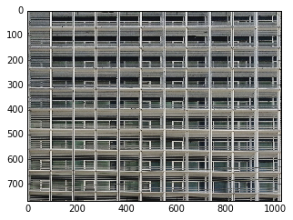

### 1.2 Generate the plots

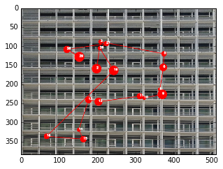

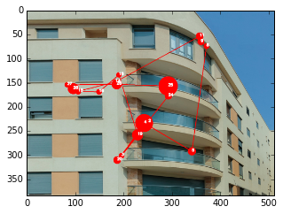

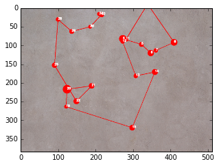

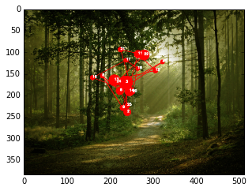

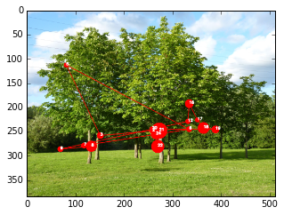

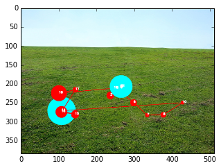

## 2. Analyze the raw data

Here we are looking for:

- Correlation in the way people look at the landscape **priority**
- Differences with the way people look at pictures

### All data by landscape

[figure not shown]

### Fixation distributions by landscape

[figure not shown]

## 3. By looking at the pictures few features might help:

- Longest fixation
- Horizontal covering (max x - min x)
- Vertical covering
- Standard deviation of x (how big are the moves)
- Standard deviation of y
- Mean of fixation
- Number of fixation

```python
dt.sample(5)
```

|  | Landscape | Subject | covered_x | covered_y | max_fix | mean_fixation | nb_move | std_x | std_y |
| --- | --- | --- | --- | --- | --- | --- | --- | --- | --- |
| 583 | 2 | 16 | 1348.47 | 744.37 | 760 | 174.763158 | 38 | 297.270289 | 200.932876 |
| 608 | 2 | 18 | 1120.16 | 923.87 | 364 | 185.435897 | 39 | 341.144459 | 292.551598 |
| 1330 | 4 | 11 | 1105.66 | 776.43 | 712 | 270.724138 | 29 | 338.886150 | 231.162109 |
| 1801 | 6 | 25 | 1287.64 | 782.46 | 488 | 163.567568 | 37 | 435.763250 | 222.572069 |
| 918 | 3 | 5 | 116.65 | 105.69 | 1626 | 497.411765 | 17 | 37.296517 | 26.926886 |

### 3.1 Just looking as the means

```python
dt.groupby('Landscape').mean()
```

| Landscape | Subject | covered_x | covered_y | max_fix | mean_fixation | nb_move | std_x | std_y |
| --- | --- | --- | --- | --- | --- | --- | --- | --- |
| 1 | 20.500000 | 976.553475 | 713.273675 | 945.375000 | 302.793310 | 26.650000 | 269.737204 | 202.290370 |
| 2 | 20.500000 | 1066.971583 | 767.910312 | 874.002083 | 269.096489 | 28.545833 | 297.363961 | 223.379025 |
| 3 | 20.595477 | 872.929824 | 664.351583 | 1178.402010 | 361.020742 | 24.839196 | 238.215687 | 184.532800 |
| 4 | 20.500000 | 915.111850 | 655.533850 | 841.960000 | 283.564306 | 27.340000 | 252.321366 | 180.446528 |
| 5 | 20.500000 | 947.957250 | 620.652150 | 1068.160000 | 336.270870 | 25.870000 | 274.324901 | 173.694350 |
| 6 | 20.500000 | 901.087950 | 574.608100 | 1122.390000 | 344.680825 | 25.220000 | 243.840014 | 160.298221 |

Already we can see that 1, 2 (building) seems to have a higher coverage on y, and 1, 2 and 4 have a smaller mean fixation

## 3.3 Visualizing groups

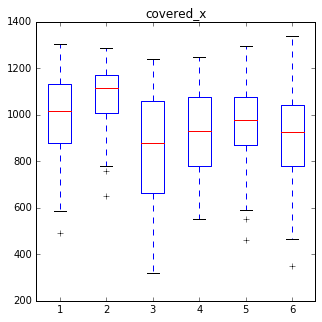

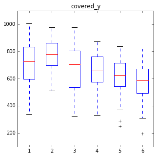

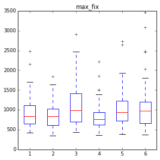

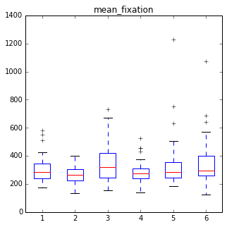

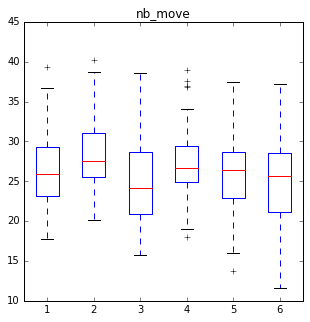

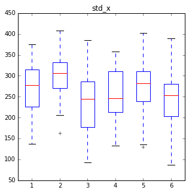

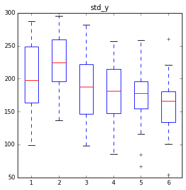

Here we see the patterns we expected for all the features!

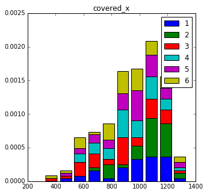

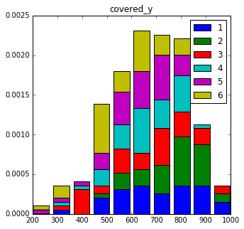

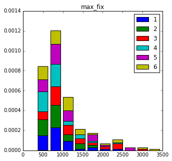

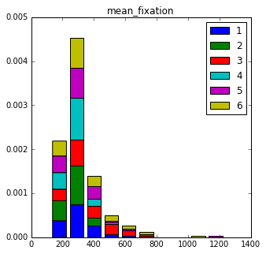

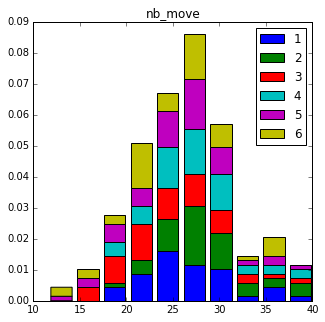

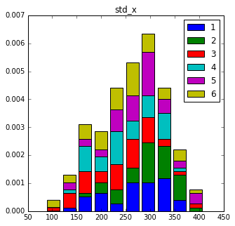

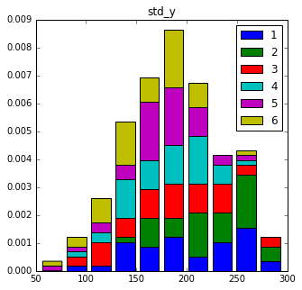

We get the same idea looking at the histograms of the values

Then looking at the same people look at different landscapes

[figure not shown]

## 4 ANOVA

[figure not shown]

## 5 Summary

- Landscapes types 1 and 2 (plain buildings, and nice architecture) and 4 (forest) are creating more moves on the eyes.
- Causes more stress
- We can also notice than the covered x and y is bigger on 2, this can be explained by the fact that pictures of 2 are more sophisticated and we want to look at them more (side effect)
- On landscapes types 3 and 6 (unicolor and grass), and also 5 a bit less (parc) we observe longer fixation, and less moves.
- More relaxing views
- Finally, one can notice that the std is usually bigger on the class 3 (homogene background), which means that people are looking at them in different ways (can be inverstigated for later researches)